# Part 1: Cleaning, Wrangling, etc.

Dylan Glave

1/19/2022

## R Markdown

This Rmd analyzes Rare’s *Fish Forever* Household Survey (shared as HHS) from 2019, to create quantitative X-Y indices of fisher compliance behavior. As of 12/7/21, we’ve used K-means Cluster Analysis to see what characteristics of compliance can be grouped into fisher “types.”

We often use *Engagement* and *Agreement* in this anaylisis, here are our working definitions and rationale:

*Engagement*

*Agreement*

To start, we’ll read in *all* relevant CSVs - `hhs_all`: a single df with the **majority** of HHS questions - `hhs` `44`, `45`, and `48`, questions that needed to be joined with the larger df

Next, we go through questions 44, 45, and 48 to remove any duplicates

We do this because, when reading in the original CSVs, we saw answers like, “Yes, Yes, Yes,” “No, No, No, No, No” and “Yes male, yes Female, Unsure.”

These questions ask respondents about their *household,* so it’s possible that they answered individually for each member of their household.

However, the goal of this analysis is to see if any single member of a household participated the management meetings, or enforcement.

To do so, we creates several df with the name `dupes...`

```r
# Check dupes for all questions
dupes_44 <- data.frame(table(hhs_q44$submissionid)) %>%
  dplyr::rename(submissionid = Var1)

dupes_45 <- data.frame(table(hhs_q45$submissionid)) %>%
  dplyr::rename(submissionid = Var1)

dupes_48 <- data.frame(table(hhs_q48$submissionid)) %>%
  dplyr::rename(submissionid = Var1)
```

The chunks below use recode_factor() to change cells within Qs 44, 45, and 48 to each have a single answer.

```r
# Cleaning data
# Question 44
hhs_q44_dupes <- hhs_q44 %>%
  inner_join(dupes_44, hhs_q44, by = "submissionid") %>%
  arrange(desc(submissionid))

# Drops rows where submissionid's with a frequency greater than 1 are labeled "Not sure"

hhs_q44_dupes <- hhs_q44_dupes[!(hhs_q44_dupes$Freq > 1 & hhs_q44_dupes$`44_meeting_attendance` == "Not sure"),]

 # Drops rows that have NA
hhs_q44_dupes <- hhs_q44_dupes[!(hhs_q44_dupes$`44_meeting_attendance` == "na"),]

# Changes "No management to "No"
hhs_q44_dupes <- hhs_q44_dupes %>%
  mutate(`44_meeting_attendance` = recode_factor(`44_meeting_attendance`, "No management" = "No"))

# Probably want to do this last
hhs_q44_dupes <- hhs_q44_dupes %>%
  group_by(submissionid, Freq) %>%
  summarise(`44_meeting_attendance` = paste(`44_meeting_attendance`, collapse = ' ')) %>%
  select(-Freq)

# Checks to see if there are any dupes left
hhs_q44_dupes_2 <- data.frame(table(hhs_q44_dupes$submissionid)) %>%
  rename(submissionid = Var1)

# Now recode the answer combos into Yes, No, & Not Sure only
hhs_q44_dupes <- hhs_q44_dupes %>%
  mutate(`44_meeting_attendance` = recode_factor(`44_meeting_attendance`, "Yes female" = "Yes"))

hhs_q44_dupes <- hhs_q44_dupes %>%
  mutate(`44_meeting_attendance` = recode_factor(`44_meeting_attendance`, "Yes male" = "Yes"))

hhs_q44_dupes <- hhs_q44_dupes %>%
  mutate(`44_meeting_attendance` = recode_factor(`44_meeting_attendance`, "Yes male Yes female" = "Yes"))

hhs_q44_dupes <- hhs_q44_dupes %>%
  mutate(`44_meeting_attendance` = recode_factor(`44_meeting_attendance`, "Yes female Yes male" = "Yes"))

hhs_q44_dupes <- hhs_q44_dupes %>%
  mutate(`44_meeting_attendance` = recode_factor(`44_meeting_attendance`, "Yes male No" = "Yes"))

hhs_q44_dupes <- hhs_q44_dupes %>%
  mutate(`44_meeting_attendance` = recode_factor(`44_meeting_attendance`, "No Yes male" = "Yes"))

hhs_q44_dupes <- hhs_q44_dupes %>%
  mutate(`44_meeting_attendance` = recode_factor(`44_meeting_attendance`, "Yes female Yes male No" = "Yes"))

hhs_q44_dupes <- hhs_q44_dupes %>%
  mutate(`44_meeting_attendance` = recode_factor(`44_meeting_attendance`, "No Yes female" = "Yes"))

hhs_q44_dupes <- hhs_q44_dupes %>%
  mutate(`44_meeting_attendance` = recode_factor(`44_meeting_attendance`, "Yes female No" = "Yes"))

hhs_q44_dupes <- hhs_q44_dupes %>%
  mutate(`44_meeting_attendance` = recode_factor(`44_meeting_attendance`, "Yes male No Yes female" = "Yes"))

hhs_q44_dupes <- hhs_q44_dupes %>%
  mutate(`44_meeting_attendance` = recode_factor(`44_meeting_attendance`, "No No" = "No"))
```

The following chunk combines duplicated from Question 45, and renames the observations that have been repeated. End result: 1 observation for each submission ID

Note: After Larissa did all the cleaning below, there was an issue with the `recode()` function. Dylan replaced each of these with `recode_factor()` and all factor levels are fine.

```r
# Question 45
hhs_q45_dupes <- hhs_q45 %>%
  inner_join(dupes_45, hhs_q45, by = "submissionid") %>%
  arrange(desc(submissionid))

# Drops rows where submissionid's with a frequency greater than 1 are labeled "Not sure"
hhs_q45_dupes <- hhs_q45_dupes[!(hhs_q45_dupes$Freq > 1 & hhs_q45_dupes$`45_leadership_position` == "Not sure"),]

# Drops rows that have NA
hhs_q45_dupes <- hhs_q45_dupes[!(hhs_q45_dupes$`45_leadership_position` == "na"),]

# Changes "No management" option to "No"
hhs_q45_dupes <- hhs_q45_dupes %>%
  mutate(`45_leadership_position` = recode_factor(`45_leadership_position`, "No management" = "No"))

# Probably want to do this last - Freq column here is artifact
hhs_q45_dupes <- hhs_q45_dupes %>%
  group_by(submissionid, Freq) %>%
  summarise(`45_leadership_position` = paste(`45_leadership_position`, collapse = ' ')) %>%
  select(-Freq)

# Checks to see if there are any dupes left
hhs_q45_dupes_2 <- data.frame(table(hhs_q45_dupes$submissionid)) %>%
  rename(submissionid = Var1)

# Now recode the answer combos into Yes, No, & Not Sure only
hhs_q45_dupes <- hhs_q45_dupes %>%
  mutate(`45_leadership_position` = recode_factor(`45_leadership_position`, "Yes female" = "Yes"))

hhs_q45_dupes <- hhs_q45_dupes %>%
  mutate(`45_leadership_position` = recode_factor(`45_leadership_position`, "Yes male" = "Yes"))

hhs_q45_dupes <- hhs_q45_dupes %>%
  mutate(`45_leadership_position` = recode_factor(`45_leadership_position`, "Yes male Yes female" = "Yes"))

hhs_q45_dupes <- hhs_q45_dupes %>%
  mutate(`45_leadership_position` = recode_factor(`45_leadership_position`, "Yes female Yes male" = "Yes"))

hhs_q45_dupes <- hhs_q45_dupes %>%
  mutate(`45_leadership_position` = recode_factor(`45_leadership_position`, "Yes male No" = "Yes"))

hhs_q45_dupes <- hhs_q45_dupes %>%
  mutate(`45_leadership_position` = recode_factor(`45_leadership_position`, "No Yes male" = "Yes"))

hhs_q45_dupes <- hhs_q45_dupes %>%
  mutate(`45_leadership_position` = recode_factor(`45_leadership_position`, "No Yes female" = "Yes"))

hhs_q45_dupes <- hhs_q45_dupes %>%
  mutate(`45_leadership_position` = recode_factor(`45_leadership_position`, "Yes female No" = "Yes"))

hhs_q45_dupes <- hhs_q45_dupes %>%
  mutate(`45_leadership_position` = recode_factor(`45_leadership_position`, "Yes male Yes male" = "Yes"))

hhs_q45_dupes <- hhs_q45_dupes %>%
  mutate(`45_leadership_position` = recode_factor(`45_leadership_position`, "No No No" = "No"))

hhs_q45_dupes <- hhs_q45_dupes %>%
  mutate(`45_leadership_position` = recode_factor(`45_leadership_position`, "No No" = "No"))
```

Below, the same happens for question 48

```r
hhs_q48_dupes <- hhs_q48 %>%
  inner_join(dupes_48, hhs_q48, by = "submissionid") %>%
  arrange(desc(submissionid))


# Drops rows where submissionid's with a frequency greater than 1 are labeled "Not sure"
hhs_q48_dupes <- hhs_q48_dupes[!(hhs_q48_dupes$Freq > 1 & hhs_q48_dupes$`48_enforcement_participation` == "Not sure"),]


# Drops rows that have NA
hhs_q48_dupes <- hhs_q48_dupes[!(hhs_q48_dupes$`48_enforcement_participation` == "na"),]

# Changes "No management" option to "No"
hhs_q48_dupes <- hhs_q48_dupes %>%
  mutate(`48_enforcement_participation` = recode_factor(`48_enforcement_participation`, "No management" = "No"))


# Change "No enforcement system" and "There is no enforcement system" to "No"
hhs_q48_dupes <- hhs_q48_dupes %>%
  mutate(`48_enforcement_participation` = recode_factor(`48_enforcement_participation`, "No enforcement system" = "No"))

hhs_q48_dupes <- hhs_q48_dupes %>%
  mutate(`48_enforcement_participation` = recode_factor(`48_enforcement_participation`, "There is no enforcement system" = "No"))

# Probably want to do this last - Freq column here is artifact
hhs_q48_dupes <- hhs_q48_dupes %>%
  group_by(submissionid, Freq) %>%
  summarise(`48_enforcement_participation` = paste(`48_enforcement_participation`, collapse = ' ')) %>%
  select(-Freq)

# Checks to see if there are any dupes left
hhs_q48_dupes_2 <- data.frame(table(hhs_q48_dupes$submissionid)) #%>%
  #rename(submissionid = Var1)

# Now recode the answer combos into Yes, No, & Not Sure only
hhs_q48_dupes <- hhs_q48_dupes %>%
  mutate(`48_enforcement_participation` = recode_factor(`48_enforcement_participation`, "Yes female" = "Yes"))

hhs_q48_dupes <- hhs_q48_dupes %>%
  mutate(`48_enforcement_participation` = recode_factor(`48_enforcement_participation`, "Yes male" = "Yes"))

hhs_q48_dupes <- hhs_q48_dupes %>%
  mutate(`48_enforcement_participation` = recode_factor(`48_enforcement_participation`, "Yes male Yes female" = "Yes"))

hhs_q48_dupes <- hhs_q48_dupes %>%
  mutate(`48_enforcement_participation` = recode_factor(`48_enforcement_participation`, "Yes female Yes male" = "Yes"))

hhs_q48_dupes <- hhs_q48_dupes %>%
  mutate(`48_enforcement_participation` = recode_factor(`48_enforcement_participation`, "Yes male No" = "Yes"))

hhs_q48_dupes <- hhs_q48_dupes %>%
  mutate(`48_enforcement_participation` = recode_factor(`48_enforcement_participation`, "No Yes male" = "Yes"))

hhs_q48_dupes <- hhs_q48_dupes %>%
  mutate(`48_enforcement_participation` = recode_factor(`48_enforcement_participation`, "No Yes female" = "Yes"))

hhs_q48_dupes <- hhs_q48_dupes %>%
  mutate(`48_enforcement_participation` = recode_factor(`48_enforcement_participation`, "Yes female No" = "Yes"))

hhs_q48_dupes <- hhs_q48_dupes %>%
  mutate(`48_enforcement_participation` = recode_factor(`48_enforcement_participation`, "No No No" = "No"))

hhs_q48_dupes <- hhs_q48_dupes %>%
  mutate(`48_enforcement_participation` = recode_factor(`48_enforcement_participation`, "No No" = "No"))

hhs_q48_dupes <- hhs_q48_dupes %>%
  mutate(`48_enforcement_participation` = recode_factor(`48_enforcement_participation`, "Yes male No No" = "Yes"))

hhs_q48_dupes <- hhs_q48_dupes %>%
  mutate(`48_enforcement_participation` = recode_factor(`48_enforcement_participation`, "No No Yes male" = "Yes"))

hhs_q48_dupes <- hhs_q48_dupes %>%
  mutate(`48_enforcement_participation` = recode_factor(`48_enforcement_participation`, "Yes female Yes female Yes female" = "Yes"))

hhs_q48_dupes <- hhs_q48_dupes %>%
  mutate(`48_enforcement_participation` = recode_factor(`48_enforcement_participation`, "Yes female Yes male No" = "Yes"))
```

I’m quite interested in question, which is its own CSV. What does that mean? It means I ahve to do the same duplicate process ass q 44, 45, and 48.

```r
dupes_7 <- data.frame(table(hhs_q7$submissionid)) %>%
  dplyr::rename(submissionid = Var1)



hhs_q7_dupes <- hhs_q7 %>%
  inner_join(dupes_7, hhs_q7, by = "submissionid") %>%
  arrange(desc(submissionid))

# hhs_q7_dupes <- hhs_q7_dupes %>%
#   group_by(submissionid, Freq) %>%
#   summarise(`7_gender` = paste(`7_gender`, collapse = ' ',
#                                `7_age` = paste(`7_age`, collapse = ' ')))


q7_df <- hhs_q7_dupes %>%
  group_by(submissionid) %>%
   summarise_all(list(~ .[!is.na(.)][1])) %>%
  rename(household_size = Freq)


# hhs_q7_dupes <- hhs_q7_dupes[!(hhs_q7_dupes$Freq > 1),]
```

Again, `recode()` has been switched to `recode_factor()` for question 48

After recoding/cleaning, these different df were all combined into `hhs_complete_all` using `right_join`

```r
# Join the datasets after all the cleaning is done
hhs_all_48 <- right_join(hhs_q48_dupes, hhs_all, by = "submissionid")

hhs_all_45 <- right_join(hhs_q45_dupes, hhs_all_48, by = "submissionid")

hhs_all_7 <- right_join( hhs_all_45, q7_df, by = "submissionid")

hhs_all_complete <- right_join(hhs_q44_dupes, hhs_all_7, by = "submissionid") %>%
  rename(country = country.x) %>%
  rename(ma_name = ma_name.x)

write.csv(hhs_all_complete, file = "hhs_all_complete.csv")

# No need to run the above code again, I have already written a .csv with the joined datasets

hhs_all_complete <- read_csv("hhs_all_complete.csv")
```

On 12/15/21, we reloaded the `"hhs_all"` CSV file, which now includes question 4, which was missing. *“Does your community have the following? 1. Marine Reserve/No-Take Area 2. Fisheries Management Area (MPA, Managed Access Area, etc.) 3. Fisheries Management Body”*

Possible answers include:

2] “marine reserve”  
[3] “management area,marine reserve,management body”  
[4] “marine reserve,management area,management body”  
[5] “management body,management area,marine reserve”  
[6] “management area”  
[7] “management area,management body”  
[8] “marine reserve,management area”  
[9] “management area,management body,marine reserve”  
[10] “management body”  
[11] “na”  
[12] “marine reserve,management body”  
[13] “marine reserve,management body,management area”  
[14] “management area,marine reserve”  
[15] “management body,marine reserve”  
[16] “management body,marine reserve,management area”  
[17] “management body,management area”  
[18] “na,marine reserve”  
[19] “na,marine reserve,management area”  
[20] “na,management area”  
[21] “marine reserve,na”  
[22] “na,marine reserve,management area,management body” [23] “management area,na”  
[24] “none”  
[25] “marine reserve,management body,na”  
[26] “marine reserve,none”

Let’s..rename some of these.

```r
hhs_all_complete_4_test <- hhs_all_complete %>%
  mutate(`4_ma_r_mb` = recode_factor(`4_ma_r_mb`,
               "marine reserve" = "Reserve",             # [2]
              "management area,marine reserve,management body" = "All 3", #[3]
              "marine reserve,management area,management body" = "All 3", # [4]
              "management body,management area,marine reserve" = "All 3", # [5],
              "management area" = "MA",                                   # [6]
              "management area,management body"       =     "MA and FMB", # [7],
              "marine reserve,management area"      = "MA and Reserve",   # [8]
              "management area,management body,marine reserve" = "All 3", # [9]
              "management body"  = "MA",                                 # [10]
              "na" = "none",                                             # [11]
              "marine reserve,management body" = "MA and FMB",           # [12]
              "marine reserve,management body,management area" = "All 3", # [13]
              "management area,marine reserve" =  "MA and Reserve",      # [14]
              "management body,marine reserve" =  "MA and FMB",           # [15]
              "management body,marine reserve,management area"  = "All 3", # [16]
              "management body,management area" = "MA and FMB",           # [17]
              "na,marine reserve" = "Reserve",                            # [18]
              "na,marine reserve,management area" = "MA and Reserve",     # [19]
              "na,management area" = "MA",                                # [20]
              "marine reserve,na" = "MA",                                # [21]
              "na,marine reserve,management area,management body" = "All 3", # [22]
              "management area,na" =  "MA",                             # [23]
              "marine reserve,management body,na" = "MA and Reserve",    # [25]
              "marine reserve,none" = "MA"))

counts_x4 <-
  hhs_all_complete_4_test %>%
  count(`4_ma_r_mb`)
```

Here is a quick summary table of the total number of responses, which matches the **original** number of surveys completed 17712

```r
# Get list of all reserves by country & how many HH surveys were answered
summary <- hhs_all_complete %>%
  count(country, level1_name, level2_name, ma_name) %>%
  #arrange(-n) %>%
  mutate(level1_name = fct_reorder(country, n, sum)) %>%
  adorn_totals("row")

# Summary table contains two NA's in the 'ma_name' column
# 75 reserves if you look at uniques
```

##### Filtering Cleaned Data

Alright!

This marks the end of the “cleaning” data section. The final two dataframes (hhs_all_complete and summary) have each survey response as 1 row, with no duplicates, and questions that were answered multiple times (44, 45, and 48) now have 1 answer of *Yes, No,* or *Unsure*.

##### Filtering out NAs:

*Goal: A robust df with only observations (survey respondents) who have answered every engagement and agreement question.*

Engagement includes questions 44, 45, 48, 53, 61g.  
Agreement includes questions 43, 46, 52, 61a, 61f, 30a

This will be called **`hhs_complete_filtered`**

First, let me get counts of the NAs that we are changing to neutral for Q 44 and 45. We think these two will filter out a large amount of observations:

```r
counts_44_45 <- hhs_all_complete %>%
  data.frame() %>%
  clean_names() %>%
  count(x44_meeting_attendance, x45_leadership_position)

counts_43 <- hhs_all_complete %>%
  data.frame() %>%
  clean_names() %>%
  count(x43_ma_benefits)
```

This filters out 1000s of observations, which we accept. We want to observe responses from fishers who took part in all the relevant survey questions.

```r
 hhs_complete_filtered <- hhs_all_complete %>%
  data.frame() %>%
  clean_names() %>%
 select( c(1:2, 6:26, x44_meeting_attendance, x45_leadership_position,
x48_enforcement_participation,  x53_encourage_regulations,
 x61g_fishing_change_behavior,
            x43_ma_benefits, x46_represent_interests,  x52_ma_benefit_5yrs, x53_encourage_regulations, x61a_current_regulations, x61f_rights_distribution_fair,
x30_trust_local_decision,
x67_reserve_boundry,
x11a_income_farming, x11a_months_farming, x11b_income_harvesting, x11b_months_harvesting, x11c_income_fishing_artisanal,  x11c_months_fishing_artisanal, x11d_income_fishing_industrial,
x11d_months_fishing_industrial, x11e_income_buying_trading, x11e_months_buying_trading, x11f_income_processing, x11f_months_processing, x11g_income_aquaculture, x11g_months_aquaculture, x11h_income_extraction,
x11h_months_extraction, x11i_income_tourism, x11i_months_tourism,   x11j_income_other_wage, x11j_months_other_wage, x11k_income_other,
x11k_months_other, x11k_other_source,
x12a_fishing_men, x12b_fishing_women, x12c_fishing_children,
x19_current_fish_catch,
x22_catch_5yrs, x17_fishing_low_profit, x18_fishing_high_profit,
x23_job_secure, x26_fishing_income_save, x28_buyer_loans, x29_family_income,
x30_trust_community,x30_trust_community_neighbors, x30_trust_fishers_community,
x30_trust_fishers_other,
x30_trust_ngo, x30_trust_regional_decision, x30_trust_religious_leaders,
x30_trust_village_alert, x31_my_community_ability,
x38_reserve_fishing_allowed,
x39_ma_boundaries_aware,
x40_reserve_boundaries_aware,
x49_enforcement_responsible,
x50_ma_punishment,
x51a_fishers_gear_not_permitted, x51b_fishers_reserves,
x51c_fishers_ma_area, x51d_fishers_violate_fish_size, x51e_fishers_caught,
x55_worry_food, x55_worry_food,
x56_reduce_meal_size_adult,  x59_food_procurement,
x60_hh_fish_consumption,
x61b_catch_recording, x61c_community_participation, x61d_strong_enforcement,
x61h_individual_behavior,
x61i_help_neighbors,
x66_reaction_fishing_reserve, x66_response_fishing_reserve, x62_reserve_compliance, x63_fishing_in_reserve, x64_wrong_fishing_reserve, x21_boat_owner_status,
x32_fishery_benefit_equal,
x51b_fishers_reserves,
x70_hh_average_income,
x7_gender, x7_age, x7_relationship, x7_gender, x7_education, household_size,
x54_food_availability)) %>%
 # mutate_at(c(24:25), ~replace(., is.na(.), 0)) %>%
   drop_na(24:34) %>%
    filter(x53_encourage_regulations != "No regulations")  %>%
    filter(x46_represent_interests != "No management") %>%
    filter(x52_ma_benefit_5yrs != "No management") %>%
  filter(x30_trust_local_decision != "6")
```

You won’t see this method step in the code, as we’e removed it, but it is worth noting that our indices evolved as we scrutinzed the definitions fo Engagement and Agreement.

- *Dropping NAs*: We drop NAs for all Engagement and Agreement Questions.
- *For Q 46-47* we’ve excluded NAs since they mostly represent “non-fisher households” The difference in n goes from 5640 to ~4500. We want to see how *fishers* comply though. So the smaller N will show us that.

*12/27/21*

We’re adding 1 question to the Agreement index, either `x30_trust_local_decision` or `30_trust_regional_decision`

I’ll run a `corplot` how the two questions compare

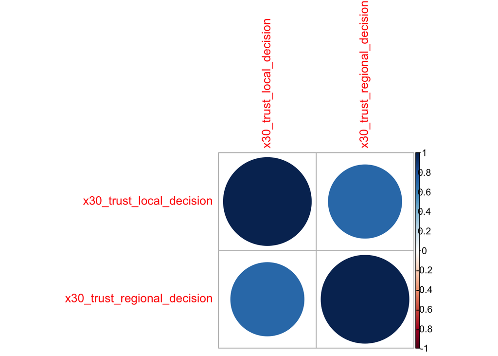

```r
x30_compared <-
  hhs_complete_filtered %>%
  select(x30_trust_local_decision, x30_trust_regional_decision) %>%
  drop_na()

corrplot(cor(x30_compared))
```

#### Quantitiative values of survey Answers

Let me list out which A and E questions have binary responses, for those that have “neither agree nor disagree,” then I’ll move from -1 to 1, with a neutral option 0. From here, I change all 10 index-components (thr 10 questions) into numeric variables.

###### Agreement

I’ll start converting the straightforward questions to 1s and 0s. **Because there was so much much dang coding in the global_filtered, I’ll make a new df for the numbered version. We’ll call it** hhs_filtered_numeric**

###### Engagement

NOTE TO DYL, INCLUDE 2-3 WORD IDNICATOR PER QUESTION BELOW Quantification list:

###### Agreement

- 43: Yes/No: (1,0,-1)
- 46: Agree/Neither/Disagree: (1,0,-1)
- 52: Yes/Unsure-No management-na/No: (1,0,-1)
- 61(a): Likert Scale (Strongly) Agree-Disagree 1-5
- 61(e): Likert Scale (Strongly) Agree-Disagree 1-5

The chunk below uses `mutate()` and `recode_factor` to complete the numeration above.

```r
hhs_filtered_numeric <- hhs_complete_filtered %>%
 mutate(x44_meeting_attendance = recode_factor(x44_meeting_attendance, "Yes" = "1", "No"  = "-1", "Not sure" = "0")) %>%
  mutate(x45_leadership_position = recode_factor(x45_leadership_position, "Yes" = 1, "No"  = -1, "Not sure" = 0, "0" = 0)) %>%
  mutate(x48_enforcement_participation = recode_factor(x48_enforcement_participation, "Yes" = 1, "No"  = -1, "Not sure" = 0, "0" = 0))  %>%
   mutate(x53_encourage_regulations = recode_factor(x53_encourage_regulations,    "Never" = -2, "Rarely" = -1, "Sometimes" = 0,
"Often" = 1, "Very often" = 2)) %>%
# mutate(x67_reserve_boundry = recode_factor(x67_reserve_boundry,
#                                           "1" = "1",
#                                           "0" = "-1",
#                                            "-1" = "0")) %>%
## 61 e and h are already coded for likert scale


## Agreement recoding below:

mutate(x46_represent_interests = recode_factor(x46_represent_interests,    "Agree" = 1, "Disagree" = -1, "Neither" = 0,
  "na" = 0)) %>%
 mutate(x52_ma_benefit_5yrs = recode_factor(x52_ma_benefit_5yrs, "Yes" = 1, "No"  = -1, "Unsure" = 0, "na" = 0)) %>%
  mutate(x62_reserve_compliance = recode_factor(x62_reserve_compliance,
    "go up" = 1, "3. La captura de los pescadores aumentará" = 1,
        "stay same" = 0, "2. La captura de los pescadores seguirá igual"  = 0,       "not know"  = 0, "4. No sabe" = 0,
         "go down" = -1, "La captura de los pescadores disminuirá" = -1)) %>%
  mutate(x64_wrong_fishing_reserve = recode_factor(x64_wrong_fishing_reserve,
     "extremely wrong" = 5, "5. Extremadamente malo" = 5,
     "very wrong" = 4, "4. Muy malo" = 4,
       "moderately" = 3, "3. Moderadamente malo" = 3,
 "Un poquito malo" = 2,   "slightly" = 2,
           "1. Nada malo" = 1,  "not at all" = 1, "na" = 0)) %>%
   mutate(x4_ma_r_mb = recode_factor(x4_ma_r_mb,
               "marine reserve" = "Reserve",             # [2]
              "management area,marine reserve,management body" = "All 3", #[3]
              "marine reserve,management area,management body" = "All 3", # [4]
              "management body,management area,marine reserve" = "All 3", # [5],
              "management area" = "MA",                                   # [6]
              "management area,management body"       =     "MA and FMB", # [7],
              "marine reserve,management area"      = "MA and Reserve",   # [8]
              "management area,management body,marine reserve" = "All 3", # [9]
              "management body"  = "MA",                                 # [10]
              "na" = "none",                                             # [11]
              "marine reserve,management body" = "MA and FMB",           # [12]
              "marine reserve,management body,management area" = "All 3", # [13]
              "management area,marine reserve" =  "MA and Reserve",      # [14]
              "management body,marine reserve" =  "MA and FMB",           # [15]
              "management body,marine reserve,management area"  = "All 3", # [16]
              "management body,management area" = "MA and FMB",           # [17]
              "na,marine reserve" = "Reserve",                            # [18]
              "na,marine reserve,management area" = "MA and Reserve",     # [19]
              "na,management area" = "MA",                                # [20]
              "marine reserve,na" = "MA",                                # [21]
              "na,marine reserve,management area,management body" = "All 3", # [22]
              "management area,na" =  "MA",                             # [23]
              "marine reserve,management body,na" = "MA and Reserve",    # [25]
              "marine reserve,none" = "MA")) %>%
  filter_at(vars(x61a_current_regulations, x61f_rights_distribution_fair, x61g_fishing_change_behavior), all_vars((.) != 0)) %>%
    mutate_at(vars(24:33), ~as.numeric(as.character(.))) %>%
  add_row( x1  = NA,
           submissionid    = NA,
           country    = "NEUTRAL",
level1_name  = NA,
level2_name   = NA,
level4_name     = NA,
level4_id         = NA,
lat = NA,
lon = NA,
ma_name  = NA,
ma_area  = NA,
ma_status  = NA,
username = NA,
x1_interviewer = NA,
 x2_affiliation  = NA,
x3_community  = NA,
x4_ma_r_mb = NA,
x5_hh_status = NA,
 x6_gender   = NA,
x8_religion  = NA,
x8_religion_other    = NA,
  x9_region_member   = NA,
x9_region_name    = NA,
x44_meeting_attendance   = 0,
 x45_leadership_position   = 0,
x48_enforcement_participation = 0,
x53_encourage_regulations= 0,
 x61g_fishing_change_behavior  = 3,
x67_reserve_boundry = 0,
x43_ma_benefits     = 0,
x46_represent_interests =  0,
  x52_ma_benefit_5yrs  = 0,
x61a_current_regulations   = 3,
x61f_rights_distribution_fair = 3,
x30_trust_local_decision = 3,
  x11a_income_farming    = NA,
x11a_months_farming    = NA,
x11b_income_harvesting   = NA,
  x11b_months_harvesting       = NA,
x11c_income_fishing_artisanal   = NA,
x11c_months_fishing_artisanal  = NA,
  x11d_income_fishing_industrial = NA,
x11d_months_fishing_industrial = NA,
x11e_income_buying_trading     = NA,
  x11e_months_buying_trading   = NA,
x11f_income_processing      = NA,
x11f_months_processing     = NA,
  x11g_income_aquaculture    = NA,
x11g_months_aquaculture    = NA,
x11h_income_extraction      = NA,
  x11h_months_extraction    = NA,
x11i_income_tourism   = NA,
x11i_months_tourism    = NA,
  x11j_income_other_wage     = NA,
x11j_months_other_wage    = NA,
x11k_income_other      = NA,
  x11k_months_other  = NA,
x11k_other_source = NA,
x12a_fishing_men   = NA,
  x12b_fishing_women  = NA,
x12c_fishing_children  = NA,
  x19_current_fish_catch   = NA,
  x22_catch_5yrs    = NA,
x23_job_secure    = NA,
x26_fishing_income_save  = NA,
  x28_buyer_loans    = NA,
x29_family_income    = NA,
x30_trust_community   = NA,
  x30_trust_community_neighbors = NA,
  x30_trust_fishers_community = NA,
x30_trust_fishers_other   = NA,
x30_trust_ngo     = NA,
x30_trust_regional_decision  = NA,
  x30_trust_religious_leaders  = NA,
  x30_trust_village_alert   = NA,
  x31_my_community_ability  = NA,
  x38_reserve_fishing_allowed  = NA,
x39_ma_boundaries_aware   = NA,
x40_reserve_boundaries_aware   = NA,
  x49_enforcement_responsible   = NA,
x50_ma_punishment      = NA,
x51a_fishers_gear_not_permitted = NA,
  x51b_fishers_reserves       = NA,
x51c_fishers_ma_area   = NA,
x51d_fishers_violate_fish_size = NA,
  x51e_fishers_caught      = NA,
x55_worry_food      = NA,
x56_reduce_meal_size_adult     = NA,
  x59_food_procurement       = NA,
x60_hh_fish_consumption        = NA,
x61b_catch_recording     = NA,
  x61c_community_participation   = NA,
x61d_strong_enforcement   = NA,
x61h_individual_behavior       = NA,
  x61i_help_neighbors      = NA,
x66_reaction_fishing_reserve   = NA,
x66_response_fishing_reserve  = NA,
  x62_reserve_compliance  = NA,
x63_fishing_in_reserve    = NA,
x64_wrong_fishing_reserve      = NA,
 x21_boat_owner_status = NA,
x32_fishery_benefit_equal = NA,
x70_hh_average_income = NA)
```

** I added a NEUTRAL ** observation with `add_row` to map out where the true neutral fisher is on our typology. This helps up see the distribution of scaled responses around the “neutral” fisher who answered the middle response to every question.

Notes: - For the Likert scale questions that Rare coded from 0-5, I removed the 0s, since they were equivalent to NAs.

- All “No management” or “No regulations” ar gone. and all 0s have been removed from questions that rare coded from 0-5. Only 1 question made a significant change, `x61f_rights_distribution_fair`

Now, I **believe** it’s time to scale the data!

Let’s just make a quick table with the *counts* of all the survey responses that we have for analysis.

Counts by *Country*

```r
hhs_count_by_country <- hhs_filtered_numeric %>%
  count(country) %>%
  arrange(-n) %>%
  #mutate(level1_name = fct_reorder(level1_name, n, sum)) %>%
  adorn_totals("row") %>%
  rename("Country" = country) %>%
  rename("Number of surveys with all 'Agreement' and 'Engagement' questions answered" = n)

summary_2 <- hhs_complete_filtered %>%
     count(country, level1_name, level2_name, ma_name) %>%
     #arrange(-n) %>%
     mutate(level1_name = fct_reorder(country, n, sum)) %>%
     adorn_totals("row")

country_count_table <- knitr::kable(hhs_count_by_country, format = "html", caption = "Engagement and Agreement Country Summary") %>%
  #column_spec(1, italic = TRUE) %>%
  row_spec(dim(hhs_count_by_country)[1], bold = TRUE) %>%
  kable_styling(c("condensed", "responsive", "bordered"), full_width = F, position = "right") %>%
  collapse_rows(columns = 1, valign = "middle")

country_count_table
```

Engagement and Agreement Country Summary

| Country | Number of surveys with all ‘Agreement’ and ‘Engagement’ questions answered |
| --- | --- |
| PHL | 2559 |
| BRA | 673 |
| MOZ | 669 |
| HND | 339 |
| IDN | 146 |
| PLW | 37 |
| FSM | 27 |
| NEUTRAL | 1 |
| Total | 4451 |

Note that “Managed-Access Area” is a spatial measurement that Rare uses for its own management, fishers (nor government) think fot hem as community or fishery boundaries, to the best of our knowledge.

###### Scaling

I’ve run `unique()` for all the E & A questions, ensuring that we only have responses that are measurable.

Following this with a check of the “no management” answers, and how they were coded.

With the statistics, we see the new mean, sd, etc. for all the agreement and engagement question.

```r
hhs_scaled <-
  hhs_filtered_numeric %>%
  mutate_at(vars(24:33), ~as.numeric(as.character(.))) %>%

  mutate(x44_scaled = as.numeric((x44_meeting_attendance - mean(x44_meeting_attendance))/sd(x44_meeting_attendance))) %>%


  mutate(x45_scaled = (x45_leadership_position - mean(x45_leadership_position))/sd(x45_leadership_position)) %>%

  mutate(x48_scaled = (x48_enforcement_participation - mean(x48_enforcement_participation))/sd(x48_enforcement_participation)) %>%

  mutate(x53_scaled = (x53_encourage_regulations - mean(x53_encourage_regulations))/sd(x53_encourage_regulations)) %>%

  mutate(x61g_scaled = (x61g_fishing_change_behavior - mean(x61g_fishing_change_behavior))/sd(x61g_fishing_change_behavior)) %>%
  # mutate(x67_scaled = (x67_reserve_boundry - mean(x67_reserve_boundry))/sd(x67_reserve_boundry)) %>%

  ##Switch from Engagement to Agreement

 # mutate(x10_scaled = (x10_mpa_important - mean(x10_mpa_important))/ sd(x10_mpa_important)) %>%
  ## We removed question 10 from the indez
  mutate(x43_scaled = (x43_ma_benefits - mean(x43_ma_benefits))/sd(x43_ma_benefits)) %>%
  mutate(x46_scaled = (x46_represent_interests - mean(x46_represent_interests))/sd(x46_represent_interests)) %>%
#  mutate(x47_scaled = (x47_represent_contributions - mean(x47_represent_contributions))/sd(x47_represent_contributions)) %>%
  # 47 was also removed from the index
  mutate(x52_scaled = (x52_ma_benefit_5yrs - mean(x52_ma_benefit_5yrs))/sd(x52_ma_benefit_5yrs)) %>%
  mutate(x61a_scaled = (x61a_current_regulations - mean(x61a_current_regulations))/sd(x61a_current_regulations)) %>%
   mutate(x61f_scaled = (x61f_rights_distribution_fair - mean(x61f_rights_distribution_fair))/sd(x61f_rights_distribution_fair)) %>%
  mutate(x30a_scaled = (x30_trust_local_decision - mean(x30_trust_local_decision))/sd(x30_trust_local_decision))
```

I’ve double-checked the statistics on each of the above variables! Each new column has a mean of nearly 0 (3x10^-16, etc.) This gives me confidence that all the math is correct.

Since we changed `recode()` to `recode_factor()`, these stats functions would not run. By changing the values to as.numeric, all is well.

###### Index Scores

*Let’s start with `mean()` and `sum()`*

```r
scaled_sum <- hhs_scaled %>%
 rowwise() %>%
  mutate(eng_sum = sum(x44_scaled, x45_scaled, x48_scaled, x53_scaled,  x61g_scaled))  %>%
  mutate(agree_sum = sum (x43_scaled, x46_scaled, x52_scaled, x61a_scaled, x61f_scaled, x30a_scaled))  %>%
  mutate(eng_mean = mean(c(x44_scaled, x45_scaled, x48_scaled,  x53_scaled,  x61g_scaled))) %>%
  mutate(agree_mean = mean(c(x43_scaled, x46_scaled, x52_scaled,  x61a_scaled,  x61f_scaled, x30a_scaled))) %>%
  rowwise() %>%
  mutate(raw_agree_mean = mean(c(x43_ma_benefits, x46_represent_interests, x52_ma_benefit_5yrs, x61a_current_regulations, x61f_rights_distribution_fair, x30_trust_local_decision))) %>%
   mutate(raw_eng_mean = mean(c(x44_meeting_attendance, x45_leadership_position, x48_enforcement_participation, x53_encourage_regulations, x61g_fishing_change_behavior)))

    ## Below I add two more variables:  "raw_eng_sum" and "raw_agree_sum." Without scaling, I've summed agreement and engagement across rows, for exploratory visualization
 # mutate(raw_eng_sum = sum(c(x44_meeting_attendance, x45_leadership_position, x48_enforcement_participation, x53_encourage_regulations, x61g_fishing_change_behavior))) %>%
#  mutate(raw_agree_sum = sum(c(x43_ma_benefits, x46_represent_interests, x52_ma_benefit_5yrs, x61a_current_regulations, x61f_rights_distribution_fair, x64_wrong_fishing_reserve)))
```

`scaled_sum` is the main df used for A/E visualization and analysis. It includes the `agree_mean` and `eng_mean` index variables, as well as dozens of other survey variables that we look at in relation to our indices.

**Since I’ve done a lot of analysis that takes away from the streamlined narrative here, I’m going to `write.csv` for scaled_sum, and add those (like graphs of each individual question) visualizations, etc. into another .Rmd**

```r
write.csv(scaled_sum, "scaled_sum.csv", row.names = FALSE)
```

`side_analysis.Rmd` contains the following analyses and visualizations:

- Bar Graphs for each A & E Question (to see the spread of responses, by question)
- Cluster analysis for *seperately* Agreement and Engagement
- UNSCALED K-Means Clustering (Was in use, up until 11/17/21)
- A large amount of visualizations for the unscaled Cluster analysis above

```r
hhs_scaled <-
  hhs_filtered_numeric %>%
  mutate_at(vars(24:33), ~as.numeric(as.character(.))) %>%

  mutate(x44_scaled = as.numeric((x44_meeting_attendance - mean(x44_meeting_attendance))/sd(x44_meeting_attendance))) %>%


  mutate(x45_scaled = (x45_leadership_position - mean(x45_leadership_position))/sd(x45_leadership_position)) %>%

  mutate(x48_scaled = (x48_enforcement_participation - mean(x48_enforcement_participation))/sd(x48_enforcement_participation)) %>%

  mutate(x53_scaled = (x53_encourage_regulations - mean(x53_encourage_regulations))/sd(x53_encourage_regulations)) %>%

  mutate(x61g_scaled = (x61g_fishing_change_behavior - mean(x61g_fishing_change_behavior))/sd(x61g_fishing_change_behavior)) %>%
  # mutate(x67_scaled = (x67_reserve_boundry - mean(x67_reserve_boundry))/sd(x67_reserve_boundry)) %>%

  ##Switch from Engagement to Agreement

 # mutate(x10_scaled = (x10_mpa_important - mean(x10_mpa_important))/ sd(x10_mpa_important)) %>%
  ## We removed question 10 from the indez
  mutate(x43_scaled = (x43_ma_benefits - mean(x43_ma_benefits))/sd(x43_ma_benefits)) %>%
  mutate(x46_scaled = (x46_represent_interests - mean(x46_represent_interests))/sd(x46_represent_interests)) %>%
#  mutate(x47_scaled = (x47_represent_contributions - mean(x47_represent_contributions))/sd(x47_represent_contributions)) %>%
  # 47 was also removed from the index
  mutate(x52_scaled = (x52_ma_benefit_5yrs - mean(x52_ma_benefit_5yrs))/sd(x52_ma_benefit_5yrs)) %>%
  mutate(x61a_scaled = (x61a_current_regulations - mean(x61a_current_regulations))/sd(x61a_current_regulations)) %>%
   mutate(x61f_scaled = (x61f_rights_distribution_fair - mean(x61f_rights_distribution_fair))/sd(x61f_rights_distribution_fair)) %>%
  mutate(x30a_scaled = (x30_trust_local_decision - mean(x30_trust_local_decision))/sd(x30_trust_local_decision))
```

I’ve double-checked the statistics on each of the above variables! Each new column has a mean of nearly 0 (3x10^-16, etc.) This gives me confidence that all the math is correct.

Since we changed `recode()` to `recode_factor()`, these stats functions would not run. By changing the values to as.numeric, all is well.

###### Index Scores

*Let’s start with `mean()` and `sum()`*

```r
scaled_sum <- hhs_scaled %>%
 rowwise() %>%
  mutate(eng_sum = sum(x44_scaled, x45_scaled, x48_scaled, x53_scaled,  x61g_scaled))  %>%
  mutate(agree_sum = sum (x43_scaled, x46_scaled, x52_scaled, x61a_scaled, x61f_scaled, x30a_scaled))  %>%
  mutate(eng_mean = mean(c(x44_scaled, x45_scaled, x48_scaled,  x53_scaled,  x61g_scaled))) %>%
  mutate(agree_mean = mean(c(x43_scaled, x46_scaled, x52_scaled,  x61a_scaled,  x61f_scaled, x30a_scaled))) %>%
  rowwise() %>%
  mutate(raw_agree_mean = mean(c(x43_ma_benefits, x46_represent_interests, x52_ma_benefit_5yrs, x61a_current_regulations, x61f_rights_distribution_fair, x30_trust_local_decision))) %>%
   mutate(raw_eng_mean = mean(c(x44_meeting_attendance, x45_leadership_position, x48_enforcement_participation, x53_encourage_regulations, x61g_fishing_change_behavior)))

    ## Below I add two more variables:  "raw_eng_sum" and "raw_agree_sum." Without scaling, I've summed agreement and engagement across rows, for exploratory visualization
 # mutate(raw_eng_sum = sum(c(x44_meeting_attendance, x45_leadership_position, x48_enforcement_participation, x53_encourage_regulations, x61g_fishing_change_behavior))) %>%
#  mutate(raw_agree_sum = sum(c(x43_ma_benefits, x46_represent_interests, x52_ma_benefit_5yrs, x61a_current_regulations, x61f_rights_distribution_fair, x64_wrong_fishing_reserve)))
```

`scaled_sum` is the main df used for A/E visualization and analysis. It includes the `agree_mean` and `eng_mean` index variables, as well as dozens of other survey variables that we look at in relation to our indices.

**Since I’ve done a lot of analysis that takes away from the streamlined narrative here, I’m going to `write.csv` for scaled_sum, and add those (like graphs of each individual question) visualizations, etc. into another .Rmd**

```r
write.csv(scaled_sum, "scaled_sum.csv", row.names = FALSE)
```